# Introdução

Este relatório tem o objetivo de comparar algoritmos para a criação de sistemas de recomendação, para isto foi feito um sistema de recomendação para cada algoritmo analisado usando para isto uma base de dados de filmes, a base de dados utilizada foi a *The Movies Dataset* disponível em: https://www.kaggle.com/rounakbanik/the-movies-dataset

A base de dados utilizada é bastante rica na quantidade informação relacionada com os filmes presentes nela, possuindo muitos atributos, desta maneira foi realizada uma análise exploratória da base de dados. O atributo da base de dados escolhido para ser utilizado pelos sistemas de recomendação desenvolvidos foi as notas que as pessoas dão para os filmes.

Os sistemas de recomendação desenvolvidos, nos códigos de programação presentes neste relatórios, são baseados nos algoritmos de *RBM* e correlação.

O *RBM* é um algoritmo que usa redes neurais para fazer recomendação de filmes, o pacote *RBM* que foi utilizado para criação do sistema pode ser obtido em: https://github.com/meownoid/tensorfow-rbm

A correlação é um algoritmo que diz o quanto duas variáveis estão correlacionadas, foi usada a correlação de Person para criar o sistema de recomendação de filmes baseado em correlação.

Os arquivos utilizados para a elaboração deste relatório podem ser obtidos em: http://rebrand.ly/2019d

# Carregamento da base de dados, filtragem e transformação dos dados

A base de dados esta divida entre vários arquivos *CSV*. Apenas dois arquivos *CSVs* da base foram utilizados neste relatório: **ratings_small.csv** e **movies_metadata.csv**.

O arquivo **movies_metadata.csv** possui informações diversas sobre os filmes, entre as informações estão: orçamento, data de lançamento, a média sobre notas que o filme recebeu e o número de pessoas que deram notas.

O arquivo **ratings_small.csv** possui a informação sobre alguns usuários que deram notas para alguns filmes, este arquivo pode ser considerado uma versão menor do arquivo **ratings.csv**. O uso do **ratings_small.csv** ao invés do **ratings.csv** é porque o **ratings.csv** possui muitos dados, isto torna o uso do **ratings.csv** computacionalmente mais custoso para as tarefas descritas neste relatório.

O dados existentes no arquivo **movies_metadata.csv** foram utilizados na análise exploratória e os dados existentes em **ratings_small.csv** foram utilizados tanto para analise exploratória quanto para criação dos sistemas recomendação. Um detalhe importante é que as notas que usuários dão para os filmes em **ratings_small.csv** esta em uma escala de 0 a 5 enquanto que a nota média que filmes possuem em **movies_metadata.csv** esta em uma escala de 0 a 10, para evitar confusões a nota média que os usuários dão para os filmes foi escalonada para 0 a 5 nos gráficos e tabelas presentes neste relatório que fazem uso deste dado.

## Carregamento base de dados que esta em arquivos *CSV* para um *data frame*

```python
#Load data base stored on csv files to data frame=====================
import pandas as pd
import numpy as np
low_memory=False
rating=pd.read_csv('databaseAtCSV/ratings_small.csv')
metadata= pd.read_csv('databaseAtCSV/movies_metadata.csv')

#np.datetime64('2018-01-18 00:00:00')
#end==================================================================
```

## Filtragem para filmes que receberam poucos votos ou que o orçamento é muito baixo

Em alguns casos os dados dos filmes carregados a partir de **movies_metadata.csv** possuem características incomuns (*outliers*), estes *outliers* atrapalham na visualização de alguns dos gráficos elaborados na análise exploratória. Para facilitar a visualização dos gráficos estes filmes com *outliers* foram desconsiderados na elaboração dos gráficos, foram considerados *outliers* filmes tenham orçamento maior ou igual que 100 milhões.

A análise exploratória busca analisar filmes populares e que tenham sido pensados para terem algum sucesso comercial, por isto filmes com as seguintes características foram desconsiderados desta análise:

- Orçamento menor que 100 mil
- Contagem de votos inferior a 51

Com estes filtros quantidade de filmes analisados a partir dos dados de **movies_metadata.csv** diminui de 45466 para 4882.

```python
def convertStringToNumber(x):
    try:
        return float(x)
    except:
        return -1

metadata['budget']=metadata['budget'].apply(convertStringToNumber)
metadataFilter=metadata[(metadata['budget']!=-1) & (metadata['budget']>100000) &(metadata['vote_count']>50)]
metadataFilter=metadataFilter[metadataFilter['budget']<(10**8)]
```

## Obtenção do dia da semana, dia do mês, mês e ano em que filme foi lançado a partir da data de lançamento

```python
import datetime
import calendar
portugueseDays={0:'Segunda',1:'Terça',2:'Quarta',3:'Quinta',4:'Sexta',5:'Sabado',6:'Domingo'}
metadataFilter['release_year']=metadataFilter['release_date'].apply(lambda x: int(x.split("-")[0]))
metadataFilter['release_month']=metadataFilter['release_date'].apply(lambda x: int(x.split("-")[1]))
metadataFilter['release_day']=metadataFilter['release_date'].apply(lambda x:  int(x.split("-")[2]) )
metadataFilter['release_day_week']=metadataFilter['release_date'].apply(lambda x:  portugueseDays[datetime.datetime(int(x.split("-")[0]), int(x.split("-")[1]),int(x.split("-")[2])).weekday()] )
```

## Agrupamento de filmes por mês de lançamento

```python
moviesReleasedByMonth=metadataFilter[['release_month','release_year','id']].groupby(['release_month','release_year']).count().reset_index().rename(columns={'id': 'nMoviesReleased'})
moviesReleasedByMonth=moviesReleasedByMonth.drop("release_year",axis=1)
moviesReleasedByMonthAndYear=metadataFilter[['release_month','release_year','id']].groupby(['release_month','release_year']).count().reset_index().rename(columns={'id': 'nMoviesReleased'})

meanForMoviesReleasedByMonth=moviesReleasedByMonth.groupby('release_month').mean()
```

## Agrupamento de filmes por dia da semana do lançamento

```python
moviesReleasedByDaysOfWeek=metadataFilter[['release_year','release_day_week','id']].groupby(['release_day_week','release_year']).count().reset_index().rename(columns={'id': 'nMoviesReleased'})
moviesReleasedByDaysOfWeek=moviesReleasedByDaysOfWeek.drop("release_year",axis=1)
#moviesReleasedByDaysOfWeek=moviesReleasedByDaysOfWeek.drop("release_month",axis=1)

meanForMoviesReleasedByDaysOfWeek= moviesReleasedByDaysOfWeek.groupby('release_day_week').mean()
```

# Análise exploratória da base de dados

## Média e desvio padrão para as notas que as pessoas dão para os filmes

A seguir estão a média e desvio padrão para as notas que os filmes recebem das pessoas:

```python
print("Média:"+str(rating['rating'].mean()))
print("Desvio padrão:"+str(rating['rating'].std()))
```

```
Média:3.543608255669773
Desvio padrão:1.0580641091070389
```

A média e o desvio padrão mostrado são calculados a partir de dados provenientes de **ratings_small.csv**, ou seja são calculadas a partir de dados que não foram filtrados, o motivo para calcular a média e o desvio padrão a partir **ratings_small.csv** é que esta informação vai ser usada para a elaboração dos sistemas de recomendação. Como dito antes os sistemas de recomendação criados usam apenas os dados provenientes de **ratings_small.csv**, por isto se calculou a média e desvio padrão para as notas a partir dos dados de **ratings_small.csv**.

## Análise para os lançamentos dos filmes ao longo dos meses dos anos

### Gráfico mostrando os boxplots para as quantidades de filmes lançados pelos meses do ano ao longo dos anos

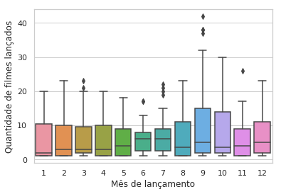

```python
import seaborn as sns
moviesReleasedByMonthPtColumns=moviesReleasedByMonth.rename(columns={'nMoviesReleased': 'Quantidade de filmes lançados', 'release_month':'Mês de lançamento'})

sns.set(style="whitegrid")
sns.boxplot(x="Mês de lançamento", y="Quantidade de filmes lançados", data=moviesReleasedByMonthPtColumns)
```

### Gráfico mostrando as médias para as quantidades de filmes lançados pelos meses do ano ao longo dos anos

```
<BarContainer object of 12 artists>
```

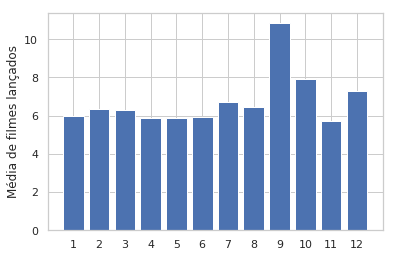

```python
import matplotlib.pyplot as plt
import numpy as np
plt.figure()
x = meanForMoviesReleasedByMonth.index
plt.xticks(x, x)
plt.ylabel('Média de filmes lançados')
plt.bar(x, height= np.transpose(meanForMoviesReleasedByMonth.values)[0])
```

### Quantidade de filmes lançados no mês 7 e 9 ao longo dos anos

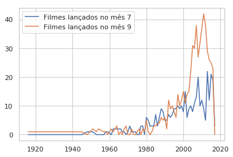

```python
import matplotlib.pyplot as plt
moviesReleasedByMonthAndYear[moviesReleasedByMonthAndYear['release_month']==7]['nMoviesReleased'].head()
moviesReleadAtMoth7=pd.DataFrame({'Filmes lançados no mês 7':moviesReleasedByMonthAndYear[moviesReleasedByMonthAndYear['release_month']==7]['nMoviesReleased'].values}, index=moviesReleasedByMonthAndYear[moviesReleasedByMonthAndYear['release_month']==7]['release_year'].values)
moviesReleadAtMoth9=pd.DataFrame({'Filmes lançados no mês 9':moviesReleasedByMonthAndYear[moviesReleasedByMonthAndYear['release_month']==9]['nMoviesReleased'].values}, index=moviesReleasedByMonthAndYear[moviesReleasedByMonthAndYear['release_month']==9]['release_year'].values)
plt.show()
pd.concat([moviesReleadAtMoth7, moviesReleadAtMoth9], axis=1, sort=False).fillna(value=0).plot()
```

## Análise para os lançamentos dos filmes ao longo dos dias da semana

A seguir estão gráficos mostrando a distribuição e média de lançamentos de filmes ao longo dos dias da semana, vários anos foram utilizados para criação destes dados. Observando os gráficos pode-se notar que sexta-feira é o dia onde mais frequentemente lançamentos ocorrem.

### Gráfico mostrando os boxplot para as quantidades de filmes lançados pelos dias da semana ao longo dos anos

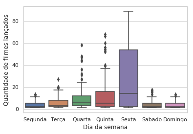

```python
import seaborn as sns
sns.set(style="whitegrid")
moviesReleasedByDaysOfWeekPtColumns=moviesReleasedByDaysOfWeek.rename(columns={'nMoviesReleased': 'Quantidade de filmes lançados', 'release_day_week':'Dia da semana'})
sns.boxplot(x="Dia da semana", y="Quantidade de filmes lançados", data=moviesReleasedByDaysOfWeekPtColumns, order=['Segunda','Terça','Quarta','Quinta','Sexta','Sabado','Domingo'])
```

### Gráfico mostrando as médias para as quantidades de filmes lançados pelos dias da semana ao longo dos anos

```
<BarContainer object of 7 artists>
```

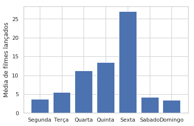

```python
import matplotlib.pyplot as plt
import numpy as np
meanForMoviesReleasedByDaysOfWeek=meanForMoviesReleasedByDaysOfWeek.reindex(['Segunda','Terça','Quarta','Quinta','Sexta','Sabado','Domingo'])

x = np.transpose(meanForMoviesReleasedByDaysOfWeek.index)
plt.xticks([0,1,2,3,4,5,6], x)
plt.ylabel('Média de filmes lançados')
plt.bar([0,1,2,3,4,5,6], height= np.transpose(meanForMoviesReleasedByDaysOfWeek.values)[0])
```

## Análise de correlação entre o orçamento do filme com a média de notas que ele recebe

A seguir estão gráficos mostrando a dispersão da média de notas que filmes recebem e seus respectivos orçamentos, não foi possível achar qualquer correlação entre estas variáveis.

### Gráficos de dispersão para os valores do orçamento dos filmes pelas médias das notas

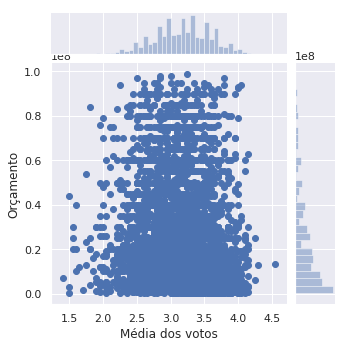

```python
import seaborn as sns
import matplotlib.pyplot as plt

sns.set_style('darkgrid')
metadataFilterPtColumns=metadataFilter.copy()
metadataFilterPtColumns=metadataFilterPtColumns.rename(columns={'vote_average': 'Média dos votos', 'budget':'Orçamento'})
sns.jointplot(height=5, x=metadataFilterPtColumns['Média dos votos']/2,y=metadataFilterPtColumns['Orçamento'])
```

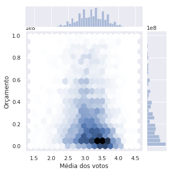

```python
sns.jointplot(height=5, x=metadataFilterPtColumns['Média dos votos']/2,y=metadataFilterPtColumns['Orçamento'],kind='hex',gridsize=20)
```

## Análise de correlação entre o orçamento do filme com o a quantidade de notas que ele recebe

A seguir estão gráficos mostrando a dispersão para o números de pessoas que dão notas para os filmes e seus respectivos orçamentos, não foi possível achar qualquer correlação entre estas variáveis.

### Gráficos de dispersão para os valores do orçamento dos filmes pelo número de notas

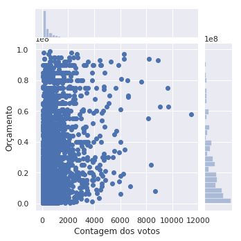

```python
metadataFilterPtColumns=metadataFilterPtColumns.rename(columns={'vote_count': 'Contagem dos votos'})
sns.jointplot(height=5, x=metadataFilterPtColumns['Contagem dos votos'],y=metadataFilterPtColumns['Orçamento'])
```

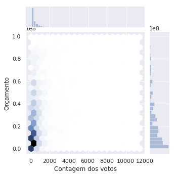

```python
sns.jointplot(height=5, x=metadataFilterPtColumns['Contagem dos votos'],y=metadataFilterPtColumns['Orçamento'],kind='hex',gridsize=20)
```

# Sistemas de recomendação

## Criação dos sistemas de recomendação

Os sistemas vão ser criados a partir do *RBM* e da correlação, além disto vai ser criado um sistema de recomendação mais simples que recomenda filmes aleatoriamente. Os dados contidos no arquivo **ratings_small.csv** foram utilizado para criar os sistemas, estes dados são linhas de uma matriz e cada linha contem o *id* (número de identificação) do filme, o *id* da pessoa e a nota que a pessoa deu para o filme. A seguir uma amostra dos dados contidos no arquivo **ratings_small.csv**:

```python
rating.head()
```

|  | userId | movieId | rating | timestamp |
| --- | --- | --- | --- | --- |
| 0 | 1 | 31 | 2.5 | 1260759144 |
| 1 | 1 | 1029 | 3.0 | 1260759179 |
| 2 | 1 | 1061 | 3.0 | 1260759182 |
| 3 | 1 | 1129 | 2.0 | 1260759185 |
| 4 | 1 | 1172 | 4.0 | 1260759205 |

De todas linhas em **ratings_small.csv** 70% delas foram escolhidas para serem parte da base de treinamento dos sistemas e 30% foram escolhidas para serem parte da base de testes dos sistemas, a escolha de que linhas foram usadas para treinamento ou para teste foi feito de maneira aleatória.

As notas contidas em **ratings_small.csv** variam de 0 a 5, contudo o sistema criado a partir do RBM só pode aceitar em seu treinamento notas que tem o valor 0 (não viu ou não gostou do filme) ou o valor 1 (gostou do filme). Por isto foi considerado que pessoas que deram uma nota maior que 4 gostaram do filme (valor 1) e pessoas que deram uma nota menor não gostaram (valor 0).

Para diminuir custo computacional de treinamento dos sistemas apenas uma parte dos filmes foram considerados no treinamento e teste dos sistemas, a escolha dos filmes que fazem parte deste conjunto é baseado no quão bem avaliado pelas pessoas um filme é considerando apenas os dados da base de treinamento. Se um filme que receber uma nota maior que 4 de uma pessoa significa que a pessoa deu uma boa avaliação para o filme, ou seja a pessoa deu um *like* para o filme. Os 1024 filmes com maior número de likes foram selecionados para fazerem parte dos filmes que são utilizados para treinar os sistemas. É importante observar que um sistema só pode recomendar filmes com quais tenha sido treinado.

```python
np.random.seed(777)
vectorUsedForRandomSelectionOfElementsAtRating= np.random.choice(range(len(rating)), len(rating), replace=False)

#Get randomly 70% of the data from rating dataframe, this is==========
#the train database===================================================
ratingToTrainTheModel=rating.loc[vectorUsedForRandomSelectionOfElementsAtRating[:round(len(rating)*0.7)]]
#end==================================================================

#Get randomly 30% of the data from rating dataframe, this is==========
#the test database. The test database and the test database don't=====
#share elements=======================================================
ratingToTestTheModel=rating.loc[vectorUsedForRandomSelectionOfElementsAtRating[round(len(rating)*0.7):]]
#end==================================================================
```

```python
ratingToTrainTheModelTemp=ratingToTrainTheModel.copy()
#Create one column of likes for ratingToTrainTheModelTemp,============
#a row has 'like' equal 1 if the field 'rating' is greater============
# greater then 7  and 'like' equal to 0 if the field==================
#'rating'  is greater or equal than ==================================
#0.5 standards deviations=============================================
stdForRatingToTrainTheModel=np.std(ratingToTrainTheModelTemp['rating'].values)
avgForRatingToTrainTheModel=np.mean(ratingToTrainTheModelTemp['rating'].values)
ratingToTrainTheModelTemp['like']=ratingToTrainTheModelTemp['rating'].apply(lambda x: 1 if(x>(avgForRatingToTrainTheModel+(0.5*stdForRatingToTrainTheModel))) else 0)
#end==================================================================

#Get the 1024 movies from ratingToTrainTheModelTemp that have=========
#more 'likes'=========================================================
sumOfLikesToThemovies=ratingToTrainTheModelTemp[['like','movieId']].groupby(['movieId']).sum()
moviesIdsWithMoreLikes=sumOfLikesToThemovies.sort_values(by=['like'],ascending=False).head(1024).index
moviesIdsWithMoreLikesHash={}
for movieId in sumOfLikesToThemovies.index:
    moviesIdsWithMoreLikesHash[movieId]=0

for movieId in moviesIdsWithMoreLikes:
    moviesIdsWithMoreLikesHash[movieId]=1
#end==================================================================
```

Criação dos artefatos utilizados nos sistemas de recomendação analisados:

```python
createMatrixToTrainRBM=True
matrixToTrainRBM=np.zeros((len(ratingToTrainTheModel['userId'].unique()),len(moviesIdsWithMoreLikes)),dtype=bool)



matrixToTrainCorrelationModel=np.zeros((len(ratingToTrainTheModel['userId'].unique()),len(moviesIdsWithMoreLikes)),dtype=float)

#Create converters from id to row or column at matrixToTrainRBM=======
convertermovieIdToColumnsOfMatricesThatWillTrainTheModels={}
convertermovieIdToVectorsPositionOfModels={}
converterUserIdToRowsOfMatricesThatWillTrainTheModels={}

rowNumber=0

for userId in ratingToTrainTheModel['userId'].unique():
    converterUserIdToRowsOfMatricesThatWillTrainTheModels[userId]=rowNumber
    rowNumber=rowNumber+1

columnNumber=0
for movieId in moviesIdsWithMoreLikes:
    convertermovieIdToColumnsOfMatricesThatWillTrainTheModels[movieId]=columnNumber
    columnNumber=columnNumber+1

convertermovieIdToVectorsPositionOfModels=convertermovieIdToColumnsOfMatricesThatWillTrainTheModels
#end==================================================================


#Create converter from position at vectors to test rbm to=============
#movie id. This converter is the inverse function of==================
#converterUserIdToRowAtMatrixToTrainRBM and===========================
#convertermovieIdToPositionAtVectorsToTestRBM=========================
converterVectorsPositionOfModelsTomovieId={}
columnNumber=0
for movieId in moviesIdsWithMoreLikes:
    converterVectorsPositionOfModelsTomovieId[columnNumber]=movieId
    columnNumber=columnNumber+1
#end==================================================================



#populate matrixToTrainRBM============================================
if(createMatrixToTrainRBM):
    registryProcessed=0
    nregistry=len(ratingToTrainTheModel)
    for registry in ratingToTrainTheModel.values:
        movieId=registry[1]
        ratting=registry[2]

        if(ratting>((stdForRatingToTrainTheModel*0.5+avgForRatingToTrainTheModel)) and (movieId in moviesIdsWithMoreLikes)):
            userId=registry[0]
            rowForUserId=converterUserIdToRowsOfMatricesThatWillTrainTheModels[userId]
            columnFormovieId=convertermovieIdToColumnsOfMatricesThatWillTrainTheModels[movieId]
            matrixToTrainRBM[rowForUserId][columnFormovieId]=True

#        if((registryProcessed%150000)==0):
#            print(str(registryProcessed)+"|"+str(nregistry))
        registryProcessed=registryProcessed+1
#end==================================================================


#populate matrixToTrainCorrelationModel===============================
registryProcessed=0
nregistry=len(ratingToTrainTheModel)
for registry in ratingToTrainTheModel.values:
    movieId=registry[1]
    ratting=registry[2]
    if(moviesIdsWithMoreLikesHash[movieId]==1):
        userId=registry[0]
        rowForUserId=converterUserIdToRowsOfMatricesThatWillTrainTheModels[userId]
        columnFormovieId=convertermovieIdToColumnsOfMatricesThatWillTrainTheModels[movieId]
        matrixToTrainCorrelationModel[rowForUserId][columnFormovieId]=ratting

#    if((registryProcessed%150000)==0):
#        print(str(registryProcessed)+"|"+str(nregistry))
    registryProcessed=registryProcessed+1
#end==================================================================
```

### Criação do sistema de recomendação usando RBM

```python
from ipywidgets import Checkbox
createRBMModel=False
cb1 = Checkbox(description='Criar novo sistema usando RBM')
createNewModels=False
def cb1Event(change):
    global createRBMModel
    createRBMModel=change['new']

cb1.observe(cb1Event, names='value')
print("Marque a caixa de seleção abaixo para gerar um novo sistema de recomendação RBM, isto vai apagar o sistema de\nrecomendação RBM gerado previamente.")
display(cb1)
```

```
Marque a caixa de seleção abaixo para gerar um novo sistema de recomendação RBM, isto vai apagar o sistema de
recomendação RBM gerado previamente.
```

```python
import json
from tfrbm import BBRBM, GBRBM

#create RBM model and save on disk====================================
if(createRBMModel):
    parametersToConstructor={
        "n_visible":len(moviesIdsWithMoreLikes),
        "n_hidden":2048,
        "learning_rate":0.001,
        "momentum":0.99,
        "use_tqdm":True
    }
    parametersToFit={
        "n_epoches":1000,
        "batch_size":32
    }
    bbrbm = BBRBM(n_visible=parametersToConstructor['n_visible'],
                  n_hidden=parametersToConstructor['n_hidden'],
                  learning_rate=parametersToConstructor['learning_rate'],
                  momentum=parametersToConstructor['momentum'],
                  use_tqdm=parametersToConstructor['use_tqdm'])

    bbrbm.fit(matrixToTrainRBM,
              n_epoches=parametersToFit['n_epoches'],
              batch_size=parametersToFit['batch_size'])


    bbrbm.save_weights('model1_dir/', 'model1')
    fp=open("model1_parametersToTheConstructor.txt","w")
    fp.write(json.dumps(parametersToConstructor))
    fp.close()
    fp=open("model1_parametersToFitMethod.txt","w")
    fp.write(json.dumps(parametersToFit))
    fp.close()
    exit()
#end==================================================================
```

### Criação do sistema de recomendação usando correlação

```python
#create correlation model=============================================
import pandas as pd
import sys
import json
createCorrelationModel=False
if(createCorrelationModel):
    print("creating correlation model")
    sys.stdout.flush()
    correlationModel=pd.DataFrame(matrixToTrainCorrelationModel, columns=moviesIdsWithMoreLikes).corr()

    print("correlation model was created")
    indexes=correlationModel.index
    correlationsForTheElements={}
    for elementIdForDataFrame in indexes:
        correlationsForTheElementIAtDataFrameWithCorrelationModel=correlationModel[elementIdForDataFrame].sort_values(ascending=False)
        elementsWithBettersRecomendationsTemp=correlationsForTheElementIAtDataFrameWithCorrelationModel.drop([elementIdForDataFrame],axis=0)
        elementsWithBettersRecomendationsTemp=elementsWithBettersRecomendationsTemp.reset_index()
        elementsCorrelated=[]
        for reg in elementsWithBettersRecomendationsTemp.values:
            elementsCorrelated.append({'elementId':reg[0],'corr':reg[1]})

        correlationsForTheElements[elementIdForDataFrame]=elementsCorrelated

    #correlationModel.to_pickle('correlationModel.pkl')
    fp =open('correlationModel.json','w')
    fp.write(json.dumps(correlationsForTheElements))
    fp.close()
    sys.stdout.flush()

#end==================================================================
```

## Teste dos sistemas de recomendação

Os sistemas criados a partir do RBM e da correlação foram comparados com um sistema simples que recomenda aleatoriamente 14 filmes entre os 20 filmes com mais *likes* para uma pessoa assistir.

A entrada para todos os sistema de recomendação é um vetor binário com 1024 elementos onde cada elemento no vetor corresponde a um filme, este vetor representa os filmes que uma dada pessoa assistiu e gostou. Se o elemento do vetor tiver valor 1 significa que a pessoa gostou daquele filme se tiver valor 0 significa que a pessoa não viu ou não gostou do filme.

A saída que os sitemas de recomendação devolvem é um vetor 1024, assim como a entrada cada elemento deste vetor corresponde a um filme e um elemento do vetor com 1 significa que pessoa vai gostar do filme, um elemento com 0 significa que a pessoa não vai gostar do filme. Uma coisa a ser observar é que todos os sistemas criados podem recomendar filmes que as pessoas já assistiram e gostaram.

### Definição de artefatos para testar os sistemas

```python
def loadUsersToTestTheModels(ratingToTrainTheModel,ratingToTestTheModel):
    users={}



    #Each position for the vectors  "movieListToPassAsInputForTheModel" and "movieListToTestModel"
    #represent an movieId the dics convertermovieIdToVectorsPositionOfModels and
    #converterVectorsPositionOfModelsTomovieId have the information about
    #the movieid and the position inside vectors that represents the movieid.
    #If the user view and liked of the movie the vector element that is pointed
    #by movieid of the movie is equal to 1, if the user don't view or don't like of the movie the
    #vector element that is pointed by movieid of the movie is equal to 0.
    createUser=lambda : {"movieListToPassAsInputForTheModel":np.zeros(1024,dtype=int), "movieListToTestModel":np.zeros(1024,dtype=int)}


    stdForRatingToTrainTheModel=np.std(ratingToTrainTheModelTemp['rating'].values)
    avgForRatingToTrainTheModel=np.mean(ratingToTrainTheModelTemp['rating'].values)
    for registry in ratingToTrainTheModel.values:
            movieId=registry[1]
            ratting=registry[2]
            if(ratting>((stdForRatingToTrainTheModel*0.5+avgForRatingToTrainTheModel)) and (movieId in moviesIdsWithMoreLikes)):
                userId=registry[0]
                if(not(userId in users)):
                    users[userId]=createUser()

                users[userId]["movieListToPassAsInputForTheModel"][convertermovieIdToVectorsPositionOfModels[movieId]]=1

    for registry in ratingToTestTheModel.values:
            movieId=registry[1]
            ratting=registry[2]
            if(ratting>((stdForRatingToTrainTheModel*0.5+avgForRatingToTrainTheModel)) and (movieId in moviesIdsWithMoreLikes)):
                userId=registry[0]
                if(not(userId in users)):
                    users[userId]=createUser()

                users[userId]["movieListToTestModel"][convertermovieIdToVectorsPositionOfModels[movieId]]=1

    return users




def countNumberOfElementsEqualsForTwoVectorsThatAreEqualToTrue(v1,v2):
    count=0
    for i in range(len(v1)):
        if(v1[i]==v2[i] and  v1[i]==True):
            count=count+1
    return count

def testModel (users,model):
    informationReturned={}
    numberOfElementsRecommendedThatTheUserWillViewList=[]
    numberOfElementsThatTheUserWillViewList=[]
    percentageForHitRecommendationsList=[]
    percentageForWrongRecommendationsList=[]
    iteration=0
    nUsers=len(users)
    numberOfElementsRecommendedList=[]
    for k in users:
        user=users[k]


        #Each position of the vector "elementsRecomended" represent an movieId
        # the dics convertermovieIdToVectorsPositionOfModels and
        #converterVectorsPositionOfModelsTomovieId has the information about
        #the movieid and the position inside vector that represents the movieid.
        #If the model predicts that the user wiil view and like of the movie the
        #vector element that is pointed by movieid of the movie is equal to 1,
        #if predicts that the user will not view or will not like of the movie the
        #vector element that is pointed by movieid of the movie is equal to 0.
        elementsRecomended=model(user["movieListToPassAsInputForTheModel"])
        elementsRecomendedCopy=np.copy(elementsRecomended)
        elementsRecomended=(elementsRecomended^user["movieListToPassAsInputForTheModel"])&elementsRecomendedCopy


        numberOfElementsThatTheUserWillView=sum(user["movieListToTestModel"]>0.5)
        numberOfElementsRecommendedThatTheUserWillView=countNumberOfElementsEqualsForTwoVectorsThatAreEqualToTrue(user["movieListToTestModel"]>0.5,elementsRecomended)
        numberOfElementsRecommended=sum(elementsRecomended)
        numberOfElementsRecommendedList.append(numberOfElementsRecommended)
        numberOfElementsRecommendedThatTheUserWillViewList.append(numberOfElementsRecommendedThatTheUserWillView)
        numberOfElementsThatTheUserWillViewList.append(numberOfElementsThatTheUserWillView)
        if(numberOfElementsRecommended>0.0):
            percentageForHitRecommendationsList.append(numberOfElementsRecommendedThatTheUserWillView/numberOfElementsRecommended)
        if(numberOfElementsRecommended>0.0):
            percentageForWrongRecommendationsList.append((numberOfElementsRecommended-numberOfElementsRecommendedThatTheUserWillView)/numberOfElementsRecommended)

        #if((iteration%1000)==0):
        #    print(str(iteration)+"|"+str(nUsers))
        iteration=iteration+1
    informationReturned['numberOfElementsRecommendedThatTheUserWillView']={'avg':np.mean(numberOfElementsRecommendedThatTheUserWillViewList),'std':np.std(numberOfElementsRecommendedThatTheUserWillViewList)}
    informationReturned['numberOfElementsThatTheUserWillViewList']={'avg':np.mean(numberOfElementsThatTheUserWillViewList),'std':np.std(numberOfElementsThatTheUserWillViewList)}
    informationReturned['percentageForHitRecommendationsList']={'avg':np.mean(percentageForHitRecommendationsList),'std':np.std(percentageForHitRecommendationsList)}
    informationReturned['percentageForWrongRecommendationsList']={'avg':np.mean(percentageForWrongRecommendationsList),'std':np.std(percentageForWrongRecommendationsList)}
    informationReturned['numberOfElementsRecommended']={'avg':np.mean(numberOfElementsRecommendedList),'std':np.std(numberOfElementsRecommendedList)}
    return informationReturned



def printInformationReturnedByTestModel(information):
    return pd.DataFrame({'Média por pessoa':['{:4.2f}'.format(information['numberOfElementsRecommendedThatTheUserWillView']['avg']),
                                             '{:4.2f}'.format(information['numberOfElementsThatTheUserWillViewList']['avg']),
                                             '{:4.2f}%'.format(information['percentageForHitRecommendationsList']['avg']*100.0),
                                             '{:4.2f}%'.format(information['percentageForWrongRecommendationsList']['avg']*100.0),
                                             '{:4.2f}'.format(information['numberOfElementsRecommended']['avg'])],
                         'Desvio padrão':   ['{:4.2f}'.format(information['numberOfElementsRecommendedThatTheUserWillView']['std']),
                                             '{:4.2f}'.format(information['numberOfElementsThatTheUserWillViewList']['std']),
                                             '{:4.2f}%'.format(information['percentageForHitRecommendationsList']['std']*100.0),
                                             '{:4.2f}%'.format(information['percentageForWrongRecommendationsList']['std']*100.0),
                                             '{:4.2f}'.format(information['numberOfElementsRecommended']['std'])]
                        },columns=["Média por pessoa","Desvio padrão"],
                        index=['Número de recomendações que foram boas',
                               'Número de  filmes da base de teste vão ser vistos',
                               'Recomendações certas',
                               'Recomendações erradas',
                               'Número  de filmes recomendados'])
    #print("                                                 ,Média por pessoa, desvio padrão ")
#    print("Número de recomendações que foram boas           ,{avg:4.6f} ,{std:4.6f}".format(avg=information['numberOfElementsRecommendedThatTheUserWillView']['avg'],std=information['numberOfElementsRecommendedThatTheUserWillView']['std']))
#    print("Número de  filmes da base de teste vão ser vistos,{avg:4.6f} ,{std:4.6f}".format(avg=information['numberOfElementsThatTheUserWillViewList']['avg'],std=information['numberOfElementsThatTheUserWillViewList']['std']))
#    print("Recomendações certas                             ,{avg:4.6f}%,{std:4.6f}".format(avg=information['percentageForHitRecommendationsList']['avg'],std=information['percentageForHitRecommendationsList']['std']))
#    print("Recomendações erradas                            ,{avg:4.6f}%,{std:4.6f}".format(avg=information['percentageForWrongRecommendationsList']['avg'],std=information['percentageForWrongRecommendationsList']['std']))
#    print("Número  de filmes recomendados                   ,{avg:4.6f},{std:4.6f}".format(avg=information['numberOfElementsRecommended']['avg'],std=information['numberOfElementsRecommended']['std']))

users=loadUsersToTestTheModels(ratingToTrainTheModel,ratingToTestTheModel)

np.random.seed(777)
#usersIdChoicedToTest=np.random.choice(list(users), round(len(users)*0.10), replace=False)
#usersChoicedToTest=dict([ (i,users[i]) for i in users if i in usersIdChoicedToTest ])
usersChoicedToTest=users
```

### Teste do sistema criado por RBM

```python
#load RBM model=======================================================
loadRBMModel=True
if(loadRBMModel):
    import json
    from tfrbm import BBRBM, GBRBM
    fp=open("model1_parametersToTheConstructor.txt","r")
    parametersToConstructor=json.loads(fp.read())
    fp.close()
    bbrbm = BBRBM(n_visible=parametersToConstructor['n_visible'],
                  n_hidden=parametersToConstructor['n_hidden'],
                  learning_rate=parametersToConstructor['learning_rate'],
                  momentum=parametersToConstructor['momentum'],
                  use_tqdm=parametersToConstructor['use_tqdm'])
    bbrbm.load_weights('model1_dir/', 'model1')
#end==================================================================

#teste RBM  model=====================================================
def predictForModelRBM(x,rbmModel):

    elementsRecomended=rbmModel.reconstruct([np.array(x,dtype=float)])[0]
    elementsRecomended=(elementsRecomended-np.mean(elementsRecomended))/np.std(elementsRecomended)
    elementsRecomended=elementsRecomended>4
    return np.array(elementsRecomended,dtype=int)

printInformationReturnedByTestModel(testModel(usersChoicedToTest,lambda x: predictForModelRBM(x,bbrbm)))
#end==================================================================
```

```
INFO:tensorflow:Restoring parameters from model1_dir/
```

|  | Média por pessoa | Desvio padrão |
| --- | --- | --- |
| Número de recomendações que foram boas | 0.77 | 0.99 |
| Número de filmes da base de teste vão ser vistos | 7.75 | 9.31 |
| Recomendações certas | 7.94% | 13.16% |
| Recomendações erradas | 92.06% | 13.16% |
| Número de filmes recomendados | 12.22 | 3.27 |

### Teste do sistema criado por correlação

```python
#load correlation model===============================================
import json
fp =open('correlationModel.json','r')
correlationModelStoredOnDict=json.loads(fp.read())
fp.close()
#end==================================================================

#test correlation model===============================================
import time

def predictForCorrelationModelStoredOnDict(x,
                                           dictWithCorrelationModel,
                                           converterPositionOfTheXVectorsToElementId,
                                           converterElementIdToPositionOfTheVectorElementsRecomended):

    elementsWithBettersRecomendations=[]
    for i in range(len(x)):
        if(x[i]==1):
            elementIdForDataFrame=str(converterPositionOfTheXVectorsToElementId[i])
            elementsWithBettersRecomendations=elementsWithBettersRecomendations+(dictWithCorrelationModel[elementIdForDataFrame][:5])

    elementsRecomended=np.zeros(len(x),dtype=int)
    if(len(elementsWithBettersRecomendations)>0):
        elementsWithBettersRecomendationsDataFrame=pd.DataFrame(elementsWithBettersRecomendations)
        idForElementsRecomended=elementsWithBettersRecomendationsDataFrame.sort_values(by=['corr'], ascending=False).head(18)['elementId'].values
        for idForElementRecomended in idForElementsRecomended:
            elementsRecomended[converterElementIdToPositionOfTheVectorElementsRecomended[idForElementRecomended]]=1

    return elementsRecomended


#t1=time.time()
printInformationReturnedByTestModel(testModel(usersChoicedToTest,lambda x: predictForCorrelationModelStoredOnDict(x,
                                                                                                                  correlationModelStoredOnDict,
                                                                                                                  converterVectorsPositionOfModelsTomovieId,
                                                                                                                  convertermovieIdToVectorsPositionOfModels)))
#t2=time.time()
#print(str(t2-t1))
#end==================================================================
```

|  | Média por pessoa | Desvio padrão |
| --- | --- | --- |
| Número de recomendações que foram boas | 0.72 | 1.00 |
| Número de filmes da base de teste vão ser vistos | 7.75 | 9.31 |
| Recomendações certas | 6.41% | 9.43% |
| Recomendações erradas | 93.59% | 9.43% |
| Número de filmes recomendados | 12.52 | 4.01 |

### Teste para sistema que recomenda filmes aleatoriamente

```python
def predictForRandomModel(x):
    elementsRecomended=np.zeros(len(x),dtype=int)
    randomChoiceToRecomendElements=np.random.choice(range(len(x))[:20], 14, replace=False)
    for i in randomChoiceToRecomendElements:
        elementsRecomended[i]=1

    return elementsRecomended

printInformationReturnedByTestModel(testModel(usersChoicedToTest,predictForRandomModel))
```

|  | Média por pessoa | Desvio padrão |
| --- | --- | --- |
| Número de recomendações que foram boas | 0.75 | 1.06 |
| Número de filmes da base de teste vão ser vistos | 7.75 | 9.31 |
| Recomendações certas | 7.23% | 11.48% |
| Recomendações erradas | 92.77% | 11.48% |
| Número de filmes recomendados | 12.12 | 2.00 |

### Análise sobre os sistemas criados

Observando os dados pode-se notar que o melhor sitemas foi aquele criado a partir do *RBM*, entretanto a acurácia do *RBM* se aproxima muito do sistema aleatório de recomendação e este sitema apresenta uma acurácia superior ao sistema criado por correlação. Uma explicação para o sistema aleatório de recomendação ter tido uma acurácia comparável ao *RBM* e superior ao de correlação é a pequena quantidade de dados com quais os sistemas foram treinados, talvez utilizando os dados existentes em **ratings.csv**, ao invés dos dados de **ratings_small.csv**, sistemas de recomendação com maior acurácia fossem criados. O motivo de não utilizar os dados existentes em **ratings.csv** para treinar os sistemas é que isto demandaria muito tempo de treino pois o arquivo **ratings.csv** tem 260 vezes mais dados que o **ratings_small.csv**.

# Conclusão

Este relatório apresentou uma análise exploratória e uma comparação entre sistemas de recomendação para a base de dados *The Movies Dataset*.

A comparação entre sistemas de recomendação comparou o acurácia de três sistemas, um criado a partir do algoritmo *RBM*, outro criado por correlação e um último mais simples que recomenda aleatoriamente 14 filmes entre os 20 mais populares. O *RBM* foi o sistema com maior acurácia, entretanto sua acurácia ficou muito próxima da acurácia obtida pelo sistema que faz recomendações aleatórias de filmes, o sistema com pior acurácia foi o sistema criado com base em correlação. Uma das possíveis causas para o sistema que faz recomendações aleatórias ter uma acurácia comparável ao RBM e superior ao sistema por correlação pode ser a pouca quantidade de dados com quais o RBM e o sistema por correlação foram treinados.